# Script 4

Yanming Di

2019-02-27

# The split-plot plant example

PLANT—from a study of the effects of CO2 and temperature on plant growth.

Twelve environmental chambers were used, with each chamber receiving a particular combination of CO2 concentration and temperature. In each chamber, twelve plants of each of three species were grown over a 127-day period. The data from the twelve plants of a particular species in a particular environmental chamber were averaged to obtain a single summary of the growth of that species in that environmental chamber. The variables are:

- chamber, 1-12
- co2, CO2 treatment:
  - 0 = ambient (380 ppm)
  - 1 = high (580 ppm),
- temp, root temperature: 0 = 13 deg C, 1 = 18 deg C
- species
  - 0 = Squirreltail, C3 grass
  - 1 = Wyoming big sagebrush, C3 shrub
  - 2 = Thurber’s needlegrass, C3 grass
- plant.wt, total plant weight
- shoot.wt, shoot weight (leaves + stems)
- root.wt, root weight
- lf.area, leaf area
- rs.ratio, root:shoot ratio (root weight / shoot weight

## Load and prepare data

```r
plant = read.table("../data/plant.txt", header=TRUE)
plant
```

```
##    chamber co2 temp species plant.wt shoot.wt root.wt lf.area rs.ratio
## 1        1   0    0       0   14.679    8.078   6.602 342.790    0.893
## 2        1   0    0       1    7.258    5.540   1.718 215.797    0.326
## 3        1   0    0       2    7.818    6.027   1.792 168.637    0.299
## 4        2   1    0       0   19.132    9.945   9.188 481.250    0.972
## 5        2   1    0       1    7.021    5.851   1.170 292.810    0.199
## 6        2   1    0       2    8.673    5.372   3.301 204.083    0.681
## 7        3   0    0       0   15.316    8.441   6.875 430.903    0.876
## 8        3   0    0       1    7.641    6.189   1.452 393.213    0.246
## 9        3   0    0       2    6.453    4.814   1.639 149.160    0.335
## 10       4   0    1       0   17.034    9.197   7.837 366.393    0.899
## 11       4   0    1       1    7.185    5.847   1.338 341.177    0.246
## 12       4   0    1       2   11.087    8.714   2.373 136.087    0.283
## 13       5   1    1       0   22.042   10.631  11.411 350.240    1.134
## 14       5   1    1       1    6.998    5.510   1.488 198.143    0.273
```

[output cut: 22 more lines]

```r
attach(plant)
co2.f <- as.factor(co2);
chamber.f <- as.factor(chamber);
species.f <- as.factor(species);
temp.f <- as.factor(temp)
```

## Plot the data

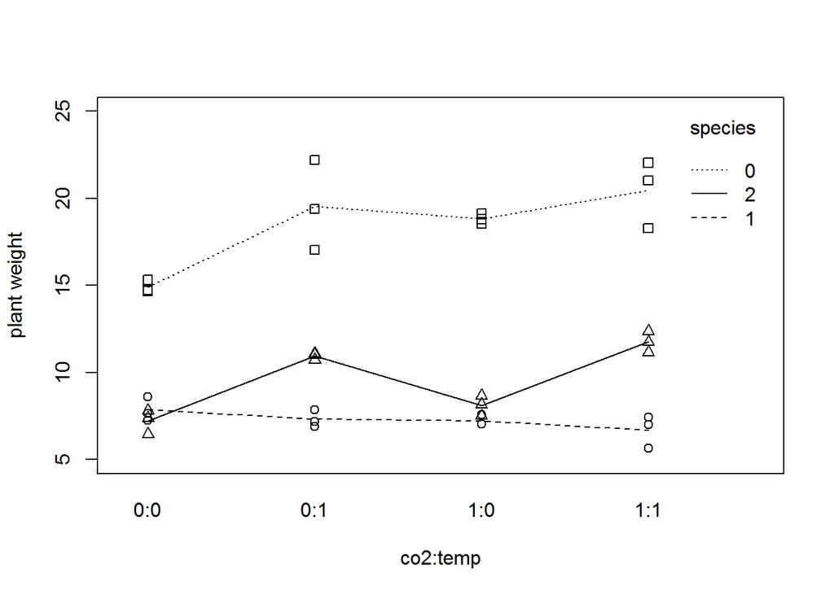

```r
f = co2.f:temp.f;
## plot(f, plant.wt, type="n");

interaction.plot(f, species, plant.wt, ylim = c(5,25), xlab="co2:temp", ylab="plant weight",);
points(f, plant.wt,  pch = species);
```

## Inference

Perform the analysis of variance. Note that a special “Error” statement was used here.

```r
m1 <- aov(plant.wt ~ co2.f*temp.f*species.f + Error(chamber.f/species.f));
summary(m1);
```

```
##
## Error: chamber.f
##              Df Sum Sq Mean Sq F value   Pr(>F)
## co2.f         1   7.00    7.00   5.865 0.041740 *
## temp.f        1  39.55   39.55  33.112 0.000427 ***
## co2.f:temp.f  1   2.38    2.38   1.991 0.195880
## Residuals     8   9.55    1.19
## ---
## Signif. codes:  0 '***' 0.001 '**' 0.01 '*' 0.05 '.' 0.1 ' ' 1
##
## Error: chamber.f:species.f
##                        Df Sum Sq Mean Sq F value   Pr(>F)
## species.f               2  837.8   418.9 380.176 3.25e-14 ***
## co2.f:species.f         2   13.9     6.9   6.304 0.009573 **
## temp.f:species.f        2   31.2    15.6  14.172 0.000287 ***
## co2.f:temp.f:species.f  2    4.4     2.2   1.997 0.168118
## Residuals              16   17.6     1.1
## ---
## Signif. codes:  0 '***' 0.001 '**' 0.01 '*' 0.05 '.' 0.1 ' ' 1
```

```r
## m1$chamber.f$effects
## m1$`chamber.f:species.f`$effects
## str(m1$chamber.f);
## str(m1$`chamber.f:species.f`);
```

(error term (1) includes $\mathtt{co2*chamber}$, $\mathtt{temp*chamber}$, and $\mathtt{co2*temp*chamber}$)

(error term (2) includes $\mathtt{species*chamber}$, $\mathtt{co2*species*chamber}$, $\mathtt{temp*species*chamber}$, and $\mathtt{co2*temp*species*chamber}$)

Note that the total number of degrees of freedom is $11 + 24 = 35$, which is one less than the total number (36) of subplots (thirds of a chamber).

We can reproduce some of the SS terms from below:

```r
m0 = lm(plant.wt ~ co2.f*temp.f*species.f
#        + co2.f*chamber.f + temp.f*chamber.f + co2.f*temp.f*chamber.f
#        + species.f*chamber.f + co2.f*species.f*chamber.f
# +temp.f*species.f*chamber.f + co2.f*temp.f*species.f*chamber.f)
        );
anova(m0)
```

```
## Analysis of Variance Table
##
## Response: plant.wt
##                        Df Sum Sq Mean Sq  F value    Pr(>F)
## co2.f                   1   7.00    7.00   6.1835 0.0202455 *
## temp.f                  1  39.55   39.55  34.9129 4.267e-06 ***
## species.f               2 837.82  418.91 369.8384 < 2.2e-16 ***
## co2.f:temp.f            1   2.38    2.38   2.0997 0.1602703
## co2.f:species.f         2  13.89    6.95   6.1327 0.0070570 **
## temp.f:species.f        2  31.23   15.62  13.7865 0.0001031 ***
## co2.f:temp.f:species.f  2   4.40    2.20   1.9431 0.1651419
## Residuals              24  27.18    1.13
## ---
## Signif. codes:  0 '***' 0.001 '**' 0.01 '*' 0.05 '.' 0.1 ' ' 1
```

Estimated effects can supposedly be obtained using the R function $\tt{model.tables}$:

```r
model.tables(m1);
```

```
## Tables of effects
##
##  co2.f
## co2.f
##       0       1
## -0.4411  0.4411
##
##  temp.f
## temp.f
##       0       1
## -1.0481  1.0481
##
##  species.f
## species.f
##      0      1      2
##  6.698 -4.471 -2.227
##
##  co2.f:temp.f
##      temp.f
## co2.f 0        1
##     0 -0.25703  0.25703
##     1  0.25703 -0.25703
##
##  co2.f:species.f
##      species.f
## co2.f 0       1       2
##     0 -0.7673  0.7543  0.0130
##     1  0.7673 -0.7543 -0.0130
##
##  temp.f:species.f
##       species.f
## temp.f 0       1       2
##      0 -0.5148  1.3074 -0.7927
##      1  0.5148 -1.3074  0.7927
##
##  co2.f:temp.f:species.f
## , , species.f = 0
##
##      temp.f
## co2.f 0       1
##     0 -0.4943  0.4943
##     1  0.4943 -0.4943
##
## , , species.f = 1
##
##      temp.f
## co2.f 0       1
##     0  0.2597 -0.2597
##     1 -0.2597  0.2597
##
## , , species.f = 2
##
##      temp.f
## co2.f 0       1
##     0  0.2346 -0.2346
##     1 -0.2346  0.2346
```

```r
## Try more exmaples to understand the Error statement
# see Venables and Ripley, p. 282-3

## m3 is the same as m1
## m3 <- aov(plant.wt ~ co2.f*temp.f*species.f + Error(chamber.f));
## summary(m3)

## m2 <- aov(plant.wt ~ co2.f*temp.f*species.f + Error(species.f))
## summary(m2)
```

## Analyzing the whole plot

For analyzing the whole plot, we can use the mean from each co2 and temp combination (i.e., Chamber means).

```r
plant.wt.1 = tapply(plant.wt, chamber, mean)
plant.1 = unique(plant[,1:3])
m2 = lm(plant.wt.1 ~ co2 * temp, data=plant.1)
anova(m2)
```

```
## Analysis of Variance Table
##
## Response: plant.wt.1
##           Df  Sum Sq Mean Sq F value    Pr(>F)
## co2        1  2.3347  2.3347  5.8646 0.0417396 *
## temp       1 13.1817 13.1817 33.1123 0.0004269 ***
## co2:temp   1  0.7928  0.7928  1.9914 0.1958801
## Residuals  8  3.1847  0.3981
## ---
## Signif. codes:  0 '***' 0.001 '**' 0.01 '*' 0.05 '.' 0.1 ' ' 1
```

## Analyzing the subplot

For analyzing the subplot (in this example, species), it is *almost* like analyzing a RCBD with the blocking factor being the chamber. Recall that in a RCBD design, when treatment is not replicated within each block, we cannot model the interactions between the block and the treatment. In this case, we cannot model interaction between chamber and species, BUT we can account for the interaction between the treatment and the two whole plot factors co2 and temp.

```r
m3 = lm(plant.wt ~ chamber.f + co2.f*temp.f * species.f);
anova(m3);
```

```
## Analysis of Variance Table
##
## Response: plant.wt
##                        Df Sum Sq Mean Sq  F value    Pr(>F)
## chamber.f              11  58.48    5.32   4.8249 0.0023966 **
## species.f               2 837.82  418.91 380.1755 3.255e-14 ***
## co2.f:species.f         2  13.89    6.95   6.3041 0.0095726 **
## temp.f:species.f        2  31.23   15.62  14.1719 0.0002873 ***
## co2.f:temp.f:species.f  2   4.40    2.20   1.9974 0.1681181
## Residuals              16  17.63    1.10
## ---
## Signif. codes:  0 '***' 0.001 '**' 0.01 '*' 0.05 '.' 0.1 ' ' 1
```

```r
## Compare the above with one where we dont' account the interactions between co2, temp and species:
m31 = lm(plant.wt ~ chamber.f + species.f);
anova(m31)
```

```
## Analysis of Variance Table
##
## Response: plant.wt
##           Df Sum Sq Mean Sq  F value    Pr(>F)
## chamber.f 11  58.48    5.32   1.7417    0.1291
## species.f  2 837.82  418.91 137.2320 3.758e-13 ***
## Residuals 22  67.16    3.05
## ---
## Signif. codes:  0 '***' 0.001 '**' 0.01 '*' 0.05 '.' 0.1 ' ' 1
```

## Analyze each species separately

An alternative (better?) approach: Fit each species separately, as a two-way ANOVA: two levels of CO2 times two levels of temperature, with three replicates (chambers) per treatment combination.

If we are mainly interested in co2 and temp effects, we can analyze each species separately.

```r
plant$co2 = factor(plant$co2);
plant$temp = factor(plant$temp);

plant0 = plant[species==0,]
plant1 = plant[species==1,]
plant2 = plant[species==2,]

m4 = lm(plant.wt ~ co2 * temp, data = plant0);
m5 = lm(plant.wt ~ co2 * temp, data = plant1);
m6 = lm(plant.wt ~ co2 * temp, data = plant2);

anova(m4);
```

```
## Analysis of Variance Table
##
## Response: plant.wt
##           Df Sum Sq Mean Sq F value  Pr(>F)
## co2        1 17.521 17.5208  6.5760 0.03342 *
## temp       1 29.309 29.3094 11.0005 0.01059 *
## co2:temp   1  6.774  6.7740  2.5424 0.14949
## Residuals  8 21.315  2.6644
## ---
## Signif. codes:  0 '***' 0.001 '**' 0.01 '*' 0.05 '.' 0.1 ' ' 1
```

```r
anova(m5);
```

```
## Analysis of Variance Table
##
## Response: plant.wt
##           Df Sum Sq Mean Sq F value Pr(>F)
## co2        1 1.1769 1.17688  2.7842 0.1337
## temp       1 0.8070 0.80705  1.9093 0.2044
## co2:temp   1 0.0001 0.00009  0.0002 0.9890
## Residuals  8 3.3816 0.42269
```

```r
anova(m6);
```

```
## Analysis of Variance Table
##
## Response: plant.wt
##           Df Sum Sq Mean Sq  F value    Pr(>F)
## co2        1  2.199   2.199   7.0714   0.02884 *
## temp       1 40.660  40.660 130.7492 3.094e-06 ***
## co2:temp   1  0.006   0.006   0.0194   0.89269
## Residuals  8  2.488   0.311
## ---
## Signif. codes:  0 '***' 0.001 '**' 0.01 '*' 0.05 '.' 0.1 ' ' 1
```